# Predict Bike Sharing Demand with AutoGluon Template

## Project: Predict Bike Sharing Demand with AutoGluon

This notebook is a template with each step that you need to complete for the project.

Please fill in your code where there are explicit `?` markers in the notebook. You are welcome to add more cells and code as you see fit.

Once you have completed all the code implementations, please export your notebook as a HTML file so the reviews can view your code. Make sure you have all outputs correctly outputted.

`File-> Export Notebook As... -> Export Notebook as HTML`

There is a writeup to complete as well after all code implememtation is done. Please answer all questions and attach the necessary tables and charts. You can complete the writeup in either markdown or PDF.

Completing the code template and writeup template will cover all of the rubric points for this project.

The rubric contains "Stand Out Suggestions" for enhancing the project beyond the minimum requirements. The stand out suggestions are optional. If you decide to pursue the "stand out suggestions", you can include the code in this notebook and also discuss the results in the writeup file.

## Step 1: Create an account with Kaggle

### Create Kaggle Account and download API key

Below is example of steps to get the API username and key. Each student will have their own username and key.

1. Open account settings.

2. Scroll down to API and click Create New API Token.

3. Open up `kaggle.json` and use the username and key.


## Step 2: Download the Kaggle dataset using the kaggle python library

### Open up Sagemaker Studio and use starter template

1. Notebook should be using a `ml.t3.medium` instance (2 vCPU + 4 GiB)
2. Notebook should be using kernal: `Python 3 (MXNet 1.8 Python 3.7 CPU Optimized)`

### Install packages

```python
!pip install -U pip
!pip install -U setuptools wheel
!pip install -U "mxnet<2.0.0" bokeh==2.0.1
!pip install autogluon --no-cache-dir
# Without --no-cache-dir, smaller aws instances may have trouble installing
```

[output not shown]

[output cut: 259 more lines]

[output not shown]

### Setup Kaggle API Key

```python
# create the .kaggle directory and an empty kaggle.json file
!mkdir -p /root/.kaggle
!touch /root/.kaggle/kaggle.json
!chmod 600 /root/.kaggle/kaggle.json
```

```python
# Fill in your user name and key from creating the kaggle account and API token file
import json
kaggle_username = "fayyazb106"
kaggle_key = "key"

# Save API token the kaggle.json file
with open("/root/.kaggle/kaggle.json", "w") as f:
    f.write(json.dumps({"username": kaggle_username, "key": kaggle_key}))
```

### Download and explore dataset

### Go to the [bike sharing demand competition](https://www.kaggle.com/c/bike-sharing-demand) and agree to the terms

```python
!pip install kaggle
# Download the dataset, it will be in a .zip file so you'll need to unzip it as well.
!kaggle competitions download -c bike-sharing-demand
# If you already downloaded it you can use the -o command to overwrite the file
!unzip -o bike-sharing-demand.zip
```

[output not shown]

```python
import pandas as pd
from autogluon.tabular import TabularPredictor
```

```python
# Create the train dataset in pandas by reading the csv
# Set the parsing of the datetime column so you can use some of the `dt` features in pandas later
train = pd.read_csv('train.csv')
train.info()
```

```
<class 'pandas.core.frame.DataFrame'>
RangeIndex: 10886 entries, 0 to 10885
Data columns (total 12 columns):
 #   Column      Non-Null Count  Dtype
---  ------      --------------  -----
 0   datetime    10886 non-null  object
 1   season      10886 non-null  int64
 2   holiday     10886 non-null  int64
 3   workingday  10886 non-null  int64
 4   weather     10886 non-null  int64
 5   temp        10886 non-null  float64
 6   atemp       10886 non-null  float64
 7   humidity    10886 non-null  int64
 8   windspeed   10886 non-null  float64
 9   casual      10886 non-null  int64
 10  registered  10886 non-null  int64
 11  count       10886 non-null  int64
dtypes: float64(3), int64(8), object(1)
memory usage: 1020.7+ KB
```

```python
train['datetime'] = pd.to_datetime(train["datetime"])
train.info()
```

```
<class 'pandas.core.frame.DataFrame'>
RangeIndex: 10886 entries, 0 to 10885
Data columns (total 12 columns):
 #   Column      Non-Null Count  Dtype
---  ------      --------------  -----
 0   datetime    10886 non-null  datetime64[ns]
 1   season      10886 non-null  int64
 2   holiday     10886 non-null  int64
 3   workingday  10886 non-null  int64
 4   weather     10886 non-null  int64
 5   temp        10886 non-null  float64
 6   atemp       10886 non-null  float64
 7   humidity    10886 non-null  int64
 8   windspeed   10886 non-null  float64
 9   casual      10886 non-null  int64
 10  registered  10886 non-null  int64
 11  count       10886 non-null  int64
dtypes: datetime64[ns](1), float64(3), int64(8)
memory usage: 1020.7 KB
```

```python
train.head()
```

|  | datetime | season | holiday | workingday | weather | temp | atemp | humidity | windspeed | casual | registered | count |
| --- | --- | --- | --- | --- | --- | --- | --- | --- | --- | --- | --- | --- |
| 0 | 2011-01-01 00:00:00 | 1 | 0 | 0 | 1 | 9.84 | 14.395 | 81 | 0.0 | 3 | 13 | 16 |
| 1 | 2011-01-01 01:00:00 | 1 | 0 | 0 | 1 | 9.02 | 13.635 | 80 | 0.0 | 8 | 32 | 40 |
| 2 | 2011-01-01 02:00:00 | 1 | 0 | 0 | 1 | 9.02 | 13.635 | 80 | 0.0 | 5 | 27 | 32 |
| 3 | 2011-01-01 03:00:00 | 1 | 0 | 0 | 1 | 9.84 | 14.395 | 75 | 0.0 | 3 | 10 | 13 |
| 4 | 2011-01-01 04:00:00 | 1 | 0 | 0 | 1 | 9.84 | 14.395 | 75 | 0.0 | 0 | 1 | 1 |

```python
# Simple output of the train dataset to view some of the min/max/varition of the dataset features.
train.describe()
```

|  | datetime | season | holiday | workingday | weather | temp | atemp | humidity | windspeed | casual | registered | count |
| --- | --- | --- | --- | --- | --- | --- | --- | --- | --- | --- | --- | --- |
| count | 10886 | 10886.000000 | 10886.000000 | 10886.000000 | 10886.000000 | 10886.00000 | 10886.000000 | 10886.000000 | 10886.000000 | 10886.000000 | 10886.000000 | 10886.000000 |
| mean | 2011-12-27 05:56:22.399411968 | 2.506614 | 0.028569 | 0.680875 | 1.418427 | 20.23086 | 23.655084 | 61.886460 | 12.799395 | 36.021955 | 155.552177 | 191.574132 |
| min | 2011-01-01 00:00:00 | 1.000000 | 0.000000 | 0.000000 | 1.000000 | 0.82000 | 0.760000 | 0.000000 | 0.000000 | 0.000000 | 0.000000 | 1.000000 |
| 25% | 2011-07-02 07:15:00 | 2.000000 | 0.000000 | 0.000000 | 1.000000 | 13.94000 | 16.665000 | 47.000000 | 7.001500 | 4.000000 | 36.000000 | 42.000000 |
| 50% | 2012-01-01 20:30:00 | 3.000000 | 0.000000 | 1.000000 | 1.000000 | 20.50000 | 24.240000 | 62.000000 | 12.998000 | 17.000000 | 118.000000 | 145.000000 |
| 75% | 2012-07-01 12:45:00 | 4.000000 | 0.000000 | 1.000000 | 2.000000 | 26.24000 | 31.060000 | 77.000000 | 16.997900 | 49.000000 | 222.000000 | 284.000000 |
| max | 2012-12-19 23:00:00 | 4.000000 | 1.000000 | 1.000000 | 4.000000 | 41.00000 | 45.455000 | 100.000000 | 56.996900 | 367.000000 | 886.000000 | 977.000000 |
| std | NaN | 1.116174 | 0.166599 | 0.466159 | 0.633839 | 7.79159 | 8.474601 | 19.245033 | 8.164537 | 49.960477 | 151.039033 | 181.144454 |

```python
# Create the test pandas dataframe in pandas by reading the csv, remember to parse the datetime!
test = pd.read_csv('test.csv')
test['datetime'] = pd.to_datetime(test["datetime"])
test.info()
```

```
<class 'pandas.core.frame.DataFrame'>
RangeIndex: 6493 entries, 0 to 6492
Data columns (total 9 columns):
 #   Column      Non-Null Count  Dtype
---  ------      --------------  -----
 0   datetime    6493 non-null   datetime64[ns]
 1   season      6493 non-null   int64
 2   holiday     6493 non-null   int64
 3   workingday  6493 non-null   int64
 4   weather     6493 non-null   int64
 5   temp        6493 non-null   float64
 6   atemp       6493 non-null   float64
 7   humidity    6493 non-null   int64
 8   windspeed   6493 non-null   float64
dtypes: datetime64[ns](1), float64(3), int64(5)
memory usage: 456.7 KB
```

```python
test.head()
```

|  | datetime | season | holiday | workingday | weather | temp | atemp | humidity | windspeed |
| --- | --- | --- | --- | --- | --- | --- | --- | --- | --- |
| 0 | 2011-01-20 00:00:00 | 1 | 0 | 1 | 1 | 10.66 | 11.365 | 56 | 26.0027 |
| 1 | 2011-01-20 01:00:00 | 1 | 0 | 1 | 1 | 10.66 | 13.635 | 56 | 0.0000 |
| 2 | 2011-01-20 02:00:00 | 1 | 0 | 1 | 1 | 10.66 | 13.635 | 56 | 0.0000 |
| 3 | 2011-01-20 03:00:00 | 1 | 0 | 1 | 1 | 10.66 | 12.880 | 56 | 11.0014 |
| 4 | 2011-01-20 04:00:00 | 1 | 0 | 1 | 1 | 10.66 | 12.880 | 56 | 11.0014 |

```python
# Same thing as train and test dataset
submission = pd.read_csv('sampleSubmission.csv')
submission['datetime'] = pd.to_datetime(submission["datetime"])
submission.info()
```

```
<class 'pandas.core.frame.DataFrame'>
RangeIndex: 6493 entries, 0 to 6492
Data columns (total 2 columns):
 #   Column    Non-Null Count  Dtype
---  ------    --------------  -----
 0   datetime  6493 non-null   datetime64[ns]
 1   count     6493 non-null   int64
dtypes: datetime64[ns](1), int64(1)
memory usage: 101.6 KB
```

```python
submission.head()
```

|  | datetime | count |
| --- | --- | --- |
| 0 | 2011-01-20 00:00:00 | 0 |
| 1 | 2011-01-20 01:00:00 | 0 |
| 2 | 2011-01-20 02:00:00 | 0 |
| 3 | 2011-01-20 03:00:00 | 0 |
| 4 | 2011-01-20 04:00:00 | 0 |

## Step 3: Train a model using AutoGluon’s Tabular Prediction

Requirements:

- We are predicting `count`, so it is the label we are setting.
- Ignore `casual` and `registered` columns as they are also not present in the test dataset.
- Use the `root_mean_squared_error` as the metric to use for evaluation.
- Set a time limit of 10 minutes (600 seconds).
- Use the preset `best_quality` to focus on creating the best model.

```python
predictor = TabularPredictor(label="count", problem_type="regression", eval_metric='root_mean_squared_error').fit(
    train_data = train.drop(['casual', 'registered'], axis=1),
    time_limit = 600,
    presets="best_quality",
)
```

[output not shown]

[output cut: 1017 more lines]

```
	-53.2715	 = Validation score   (-root_mean_squared_error)
	37.92s	 = Training   runtime
	0.63s	 = Validation runtime
Fitting model: CatBoost_BAG_L2 ... Training model for up to 59.0s of the 58.94s of remaining time.
	Fitting 8 child models (S1F1 - S1F8) | Fitting with ParallelLocalFoldFittingStrategy (2 workers, per: cpus=1, gpus=0, memory=0.86%)
	-55.3478	 = Validation score   (-root_mean_squared_error)
	59.79s	 = Training   runtime
	0.06s	 = Validation runtime
Fitting model: WeightedEnsemble_L3 ... Training model for up to 360.0s of the -5.1s of remaining time.
	Ensemble Weights: {'RandomForestMSE_BAG_L2': 0.74, 'CatBoost_BAG_L2': 0.26}
	-52.971	 = Validation score   (-root_mean_squared_error)
	0.32s	 = Training   runtime
	0.0s	 = Validation runtime
AutoGluon training complete, total runtime = 434.62s ... Best model: "WeightedEnsemble_L3"
TabularPredictor saved. To load, use: predictor = TabularPredictor.load("AutogluonModels/ag-20240415_220448")
```

### Review AutoGluon's training run with ranking of models that did the best.

```python
predictor.fit_summary()
```

```
*** Summary of fit() ***
Estimated performance of each model:
                    model   score_val              eval_metric  pred_time_val    fit_time  pred_time_val_marginal  fit_time_marginal  stack_level  can_infer  fit_order
0     WeightedEnsemble_L3  -52.971009  root_mean_squared_error       3.038417  386.351645                0.000530           0.324391            3       True         10
1  RandomForestMSE_BAG_L2  -53.271503  root_mean_squared_error       2.974236  326.240871                0.632952          37.916678            2       True          8
2         CatBoost_BAG_L2  -55.347761  root_mean_squared_error       2.404936  348.110576                0.063652          59.786383            2       True          9
3   KNeighborsDist_BAG_L1  -84.125061  root_mean_squared_error       0.044678    0.032015                0.044678           0.032015            1       True          2
4     WeightedEnsemble_L2  -84.125061  root_mean_squared_error       0.045207    0.349472                0.000529           0.317457            2       True          7
5   KNeighborsUnif_BAG_L1 -101.546199  root_mean_squared_error       0.047341    0.034938                0.047341           0.034938            1       True          1
6  RandomForestMSE_BAG_L1 -116.548359  root_mean_squared_error       0.744023   16.659337                0.744023          16.659337            1       True          3
7    ExtraTreesMSE_BAG_L1 -124.600676  root_mean_squared_error       0.719332    7.855947                0.719332           7.855947            1       True          5
8         CatBoost_BAG_L1 -130.553983  root_mean_squared_error       0.141596  195.120031                0.141596         195.120031            1       True          4
9  NeuralNetFastAI_BAG_L1 -139.278911  root_mean_squared_error       0.644313   68.621925                0.644313          68.621925            1       True          6
Number of models trained: 10
Types of models trained:
{'WeightedEnsembleModel', 'StackerEnsembleModel_RF', 'StackerEnsembleModel_XT', 'StackerEnsembleModel_CatBoost', 'StackerEnsembleModel_NNFastAiTabular', 'StackerEnsembleModel_KNN'}
Bagging used: True  (with 8 folds)
Multi-layer stack-ensembling used: True  (with 3 levels)
Feature Metadata (Processed):
(raw dtype, special dtypes):
('float', [])                : 3 | ['temp', 'atemp', 'windspeed']
('int', [])                  : 3 | ['season', 'weather', 'humidity']
('int', ['bool'])            : 2 | ['holiday', 'workingday']
('int', ['datetime_as_int']) : 5 | ['datetime', 'datetime.year', 'datetime.month', 'datetime.day', 'datetime.dayofweek']
*** End of fit() summary ***
```

[output not shown]

[output cut: 78 more lines]

```
 7    7.855947                0.719332           7.855947            1
 8  195.120031                0.141596         195.120031            1
 9   68.621925                0.644313          68.621925            1

    can_infer  fit_order
 0       True         10
 1       True          8
 2       True          9
 3       True          2
 4       True          7
 5       True          1
 6       True          3
 7       True          5
 8       True          4
 9       True          6  }
```

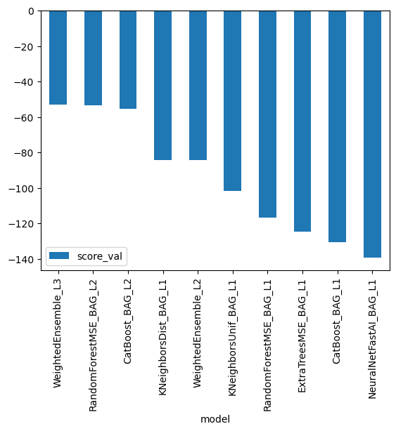

```python
predictor.leaderboard(silent=True).plot(kind="bar", x="model", y="score_val")
```

### Create predictions from test dataset

```python
predictions = predictor.predict(test)
predictions.head()
```

```
0    23.755774
1    42.861614
2    45.516068
3    49.267582
4    52.484566
Name: count, dtype: float32
```

#### NOTE: Kaggle will reject the submission if we don't set everything to be > 0.

```python
# Describe the `predictions` series to see if there are any negative values
predictions.describe()
```

```
count    6493.000000
mean      100.984879
std        90.186279
min         2.417776
25%        20.054312
50%        64.673836
75%       166.688904
max       363.825439
Name: count, dtype: float64
```

```python
# How many negative values do we have?
# Zero, the min is 2.417776 which is greater than zero
```

```python
# Set them to zero
# Not necesarry
```

### Set predictions to submission dataframe, save, and submit

```python
submission["count"] = predictions
submission.to_csv("submission.csv", index=False)
```

```python
!kaggle competitions submit -c bike-sharing-demand -f submission.csv -m "first raw submission"
```

```
Successfully submitted to Bike Sharing Demand
```

#### View submission via the command line or in the web browser under the competition's page - `My Submissions`

```python
!kaggle competitions submissions -c bike-sharing-demand | tail -n +1 | head -n 6
```

```
fileName        date                 description           status    publicScore  privateScore
--------------  -------------------  --------------------  --------  -----------  ------------
submission.csv  2024-04-15 22:33:08  first raw submission  complete  1.79568      1.79568
```

#### Initial score of `1.79568`

## Step 4: Exploratory Data Analysis and Creating an additional feature

- Any additional feature will do, but a great suggestion would be to separate out the datetime into hour, day, or month parts.

```
array([[<AxesSubplot:title={'center':'datetime'}>,
        <AxesSubplot:title={'center':'season'}>,
        <AxesSubplot:title={'center':'holiday'}>],
       [<AxesSubplot:title={'center':'workingday'}>,
        <AxesSubplot:title={'center':'weather'}>,
        <AxesSubplot:title={'center':'temp'}>],
       [<AxesSubplot:title={'center':'atemp'}>,
        <AxesSubplot:title={'center':'humidity'}>,
        <AxesSubplot:title={'center':'windspeed'}>],
       [<AxesSubplot:title={'center':'casual'}>,
        <AxesSubplot:title={'center':'registered'}>,
        <AxesSubplot:title={'center':'count'}>]], dtype=object)
```

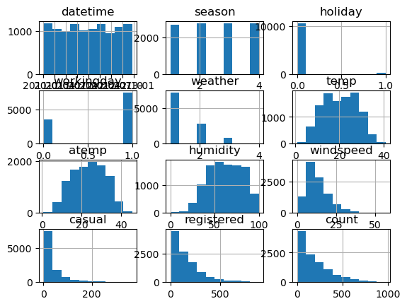

```python
# Create a histogram of all features to show the distribution of each one relative to the data. This is part of the exploritory data analysis
train.hist()
```

```python
# create a new feature
train['month'] = pd.to_datetime(train.datetime).dt.month
train['day'] = pd.to_datetime(train.datetime).dt.day
train['hour'] = pd.to_datetime(train.datetime).dt.hour

test['month'] = pd.to_datetime(test.datetime).dt.month
test['day'] = pd.to_datetime(test.datetime).dt.day
test['hour'] = pd.to_datetime(test.datetime).dt.hour
```

## Make category types for these so models know they are not just numbers

- AutoGluon originally sees these as ints, but in reality they are int representations of a category.
- Setting the dtype to category will classify these as categories in AutoGluon.

```python
train["season"] = train["season"].astype("category")
train["weather"] = train["weather"].astype("category")
test["season"] = test["season"].astype("category")
test["weather"] = test["weather"].astype("category")
```

```python
# View the new features
train.head()
```

|  | datetime | season | holiday | workingday | weather | temp | atemp | humidity | windspeed | casual | registered | count | month | day | hour |
| --- | --- | --- | --- | --- | --- | --- | --- | --- | --- | --- | --- | --- | --- | --- | --- |
| 0 | 2011-01-01 00:00:00 | 1 | 0 | 0 | 1 | 9.84 | 14.395 | 81 | 0.0 | 3 | 13 | 16 | 1 | 1 | 0 |
| 1 | 2011-01-01 01:00:00 | 1 | 0 | 0 | 1 | 9.02 | 13.635 | 80 | 0.0 | 8 | 32 | 40 | 1 | 1 | 1 |
| 2 | 2011-01-01 02:00:00 | 1 | 0 | 0 | 1 | 9.02 | 13.635 | 80 | 0.0 | 5 | 27 | 32 | 1 | 1 | 2 |
| 3 | 2011-01-01 03:00:00 | 1 | 0 | 0 | 1 | 9.84 | 14.395 | 75 | 0.0 | 3 | 10 | 13 | 1 | 1 | 3 |
| 4 | 2011-01-01 04:00:00 | 1 | 0 | 0 | 1 | 9.84 | 14.395 | 75 | 0.0 | 0 | 1 | 1 | 1 | 1 | 4 |

```python
train.info()
```

```
<class 'pandas.core.frame.DataFrame'>
RangeIndex: 10886 entries, 0 to 10885
Data columns (total 15 columns):
 #   Column      Non-Null Count  Dtype
---  ------      --------------  -----
 0   datetime    10886 non-null  datetime64[ns]
 1   season      10886 non-null  category
 2   holiday     10886 non-null  int64
 3   workingday  10886 non-null  int64
 4   weather     10886 non-null  category
 5   temp        10886 non-null  float64
 6   atemp       10886 non-null  float64
 7   humidity    10886 non-null  int64
 8   windspeed   10886 non-null  float64
 9   casual      10886 non-null  int64
 10  registered  10886 non-null  int64
 11  count       10886 non-null  int64
 12  month       10886 non-null  int32
 13  day         10886 non-null  int32
 14  hour        10886 non-null  int32
dtypes: category(2), datetime64[ns](1), float64(3), int32(3), int64(6)
memory usage: 999.8 KB
```

```
array([[<AxesSubplot:title={'center':'datetime'}>,
        <AxesSubplot:title={'center':'holiday'}>,
        <AxesSubplot:title={'center':'workingday'}>,
        <AxesSubplot:title={'center':'temp'}>],
       [<AxesSubplot:title={'center':'atemp'}>,
        <AxesSubplot:title={'center':'humidity'}>,
        <AxesSubplot:title={'center':'windspeed'}>,
        <AxesSubplot:title={'center':'casual'}>],
       [<AxesSubplot:title={'center':'registered'}>,
        <AxesSubplot:title={'center':'count'}>,
        <AxesSubplot:title={'center':'month'}>,
        <AxesSubplot:title={'center':'day'}>],
       [<AxesSubplot:title={'center':'hour'}>, <AxesSubplot:>,
        <AxesSubplot:>, <AxesSubplot:>]], dtype=object)
```

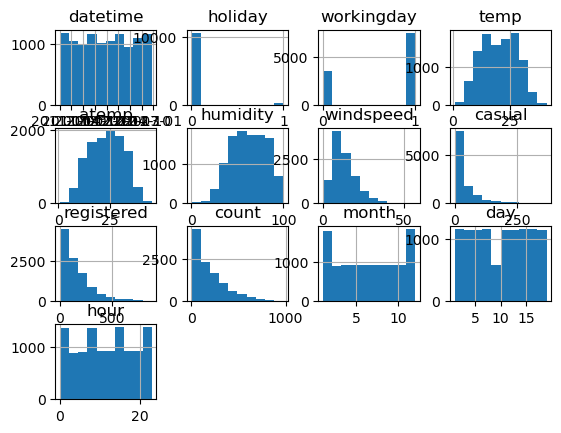

```python
# View histogram of all features again now with the hour feature
train.hist()
```

## Step 5: Rerun the model with the same settings as before, just with more features

```python
predictor_new_features = TabularPredictor(label="count", problem_type="regression", eval_metric='root_mean_squared_error').fit(
    train_data = train.drop(['casual', 'registered'], axis=1),
    time_limit = 600,
    presets="best_quality",
)
```

[output not shown]

[output cut: 992 more lines]

```
	-32.3396	 = Validation score   (-root_mean_squared_error)
	37.87s	 = Training   runtime
	0.75s	 = Validation runtime
Fitting model: CatBoost_BAG_L2 ... Training model for up to 57.61s of the 57.58s of remaining time.
	Fitting 8 child models (S1F1 - S1F8) | Fitting with ParallelLocalFoldFittingStrategy (2 workers, per: cpus=1, gpus=0, memory=0.80%)
	-30.9043	 = Validation score   (-root_mean_squared_error)
	58.8s	 = Training   runtime
	0.09s	 = Validation runtime
Fitting model: WeightedEnsemble_L3 ... Training model for up to 360.0s of the -6.09s of remaining time.
	Ensemble Weights: {'CatBoost_BAG_L2': 0.798, 'RandomForestMSE_BAG_L2': 0.143, 'CatBoost_BAG_L1': 0.048, 'KNeighborsDist_BAG_L1': 0.012}
	-30.8193	 = Validation score   (-root_mean_squared_error)
	0.41s	 = Training   runtime
	0.0s	 = Validation runtime
AutoGluon training complete, total runtime = 437.74s ... Best model: "WeightedEnsemble_L3"
TabularPredictor saved. To load, use: predictor = TabularPredictor.load("AutogluonModels/ag-20240416_150540")
```

```python
predictor_new_features.fit_summary()
```

```
*** Summary of fit() ***
Estimated performance of each model:
                    model   score_val              eval_metric  pred_time_val    fit_time  pred_time_val_marginal  fit_time_marginal  stack_level  can_infer  fit_order
0     WeightedEnsemble_L3  -30.819281  root_mean_squared_error       3.033776  389.887877                0.000559           0.407121            3       True         10
1         CatBoost_BAG_L2  -30.904349  root_mean_squared_error       2.287009  351.607264                0.093048          58.797966            2       True          9
2  RandomForestMSE_BAG_L2  -32.339600  root_mean_squared_error       2.940169  330.682789                0.746208          37.873492            2       True          8
3     WeightedEnsemble_L2  -33.180092  root_mean_squared_error       0.902136  234.487718                0.000912           0.348436            2       True          7
4         CatBoost_BAG_L1  -33.933831  root_mean_squared_error       0.176134  217.260394                0.176134         217.260394            1       True          4
5  RandomForestMSE_BAG_L1  -38.394461  root_mean_squared_error       0.679381   16.842276                0.679381          16.842276            1       True          3
6    ExtraTreesMSE_BAG_L1  -38.491830  root_mean_squared_error       0.681516    6.653100                0.681516           6.653100            1       True          5
7   KNeighborsDist_BAG_L1  -84.125061  root_mean_squared_error       0.045708    0.036613                0.045708           0.036613            1       True          2
8  NeuralNetFastAI_BAG_L1 -101.002628  root_mean_squared_error       0.561258   51.960934                0.561258          51.960934            1       True          6
9   KNeighborsUnif_BAG_L1 -101.546199  root_mean_squared_error       0.049963    0.055981                0.049963           0.055981            1       True          1
Number of models trained: 10
Types of models trained:
{'StackerEnsembleModel_RF', 'StackerEnsembleModel_XT', 'StackerEnsembleModel_KNN', 'StackerEnsembleModel_NNFastAiTabular', 'WeightedEnsembleModel', 'StackerEnsembleModel_CatBoost'}
Bagging used: True  (with 8 folds)
Multi-layer stack-ensembling used: True  (with 3 levels)
Feature Metadata (Processed):
(raw dtype, special dtypes):
('category', [])             : 2 | ['season', 'weather']
('float', [])                : 3 | ['temp', 'atemp', 'windspeed']
('int', [])                  : 4 | ['humidity', 'month', 'day', 'hour']
('int', ['bool'])            : 2 | ['holiday', 'workingday']
('int', ['datetime_as_int']) : 3 | ['datetime', 'datetime.year', 'datetime.dayofweek']
*** End of fit() summary ***
```

[output not shown]

[output cut: 78 more lines]

```
 7    0.036613                0.045708           0.036613            1
 8   51.960934                0.561258          51.960934            1
 9    0.055981                0.049963           0.055981            1

    can_infer  fit_order
 0       True         10
 1       True          9
 2       True          8
 3       True          7
 4       True          4
 5       True          3
 6       True          5
 7       True          2
 8       True          6
 9       True          1  }
```

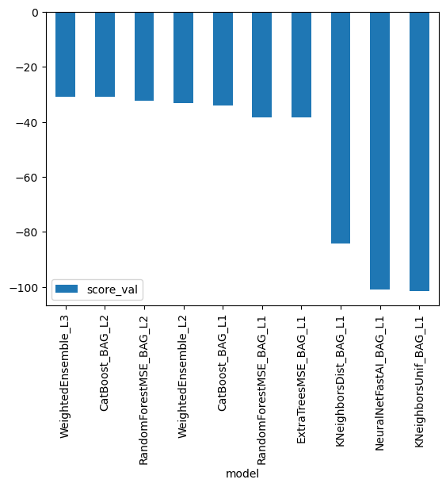

```python
predictor_new_features.leaderboard(silent=True).plot(kind="bar", x="model", y="score_val")
```

```python
predictions_new = predictor_new_features.predict(test)
predictions_new.head()
```

```
0    17.328510
1    12.308781
2    11.273167
3     9.984644
4     8.298717
Name: count, dtype: float32
```

```python
predictions_new.describe()
```

```
count    6493.000000
mean      144.031769
std       119.922119
min         0.621384
25%        56.494572
50%       117.655479
75%       195.587158
max       816.142883
Name: count, dtype: float64
```

```python
# Remember to set all negative values to zero
# Min is 0.621384 so it's not necessary
```

```python
# Same submitting predictions
submission_new_features = pd.read_csv('sampleSubmission.csv')
submission_new_features['datetime'] = pd.to_datetime(submission_new_features["datetime"])
submission_new_features.info()
```

```
<class 'pandas.core.frame.DataFrame'>
RangeIndex: 6493 entries, 0 to 6492
Data columns (total 2 columns):
 #   Column    Non-Null Count  Dtype
---  ------    --------------  -----
 0   datetime  6493 non-null   datetime64[ns]
 1   count     6493 non-null   int64
dtypes: datetime64[ns](1), int64(1)
memory usage: 101.6 KB
```

```python
submission_new_features["count"] = predictions_new
submission_new_features.to_csv("submission_new_features.csv", index=False)
```

```python
!kaggle competitions submit -c bike-sharing-demand -f submission_new_features.csv -m "new features"
```

```
Successfully submitted to Bike Sharing Demand
```

```python
!kaggle competitions submissions -c bike-sharing-demand | tail -n +1 | head -n 6
```

```
fileName                     date                 description           status    publicScore  privateScore
---------------------------  -------------------  --------------------  --------  -----------  ------------
submission_new_features.csv  2024-04-16 15:20:20  new features          complete  0.74796      0.74796
submission.csv               2024-04-15 22:33:08  first raw submission  complete  1.79568      1.79568
```

#### New Score of `0.74796`

## Step 6: Hyper parameter optimization

- There are many options for hyper parameter optimization.
- Options are to change the AutoGluon higher level parameters or the individual model hyperparameters.
- The hyperparameters of the models themselves that are in AutoGluon. Those need the `hyperparameter` and `hyperparameter_tune_kwargs` arguments.

```python
# Custom XGBoost Parameters
xgb_param = {
    "max_depth": 5,
    "eta": 0.01,
    "gamma": 0.1,
    "colsample_bytree": 0.7,
    "objective": "reg:squarederror",
}

hyperparameters = {
                   'XGB': xgb_param
                  }

# Use local FIFO scheduler and Bayes Optimization
hyperparameter_tune_kwargs = {
                            'scheduler' : 'local',
                            'searcher': 'bayes'
                            }
```

```python
predictor_new_hpo = TabularPredictor(label="count", problem_type="regression", eval_metric='root_mean_squared_error').fit(
    train_data = train.drop(['casual', 'registered'], axis=1),
    time_limit = 600,
    presets = "best_quality",
    hyperparameters = hyperparameters,
    hyperparameter_tune_kwargs = hyperparameter_tune_kwargs
)
```

[output not shown]

[output cut: 210 more lines]

```
Fitted model: XGBoost_BAG_L2/T7 ...
	-130.2863	 = Validation score   (-root_mean_squared_error)
	18.87s	 = Training   runtime
	0.0s	 = Validation runtime
Fitted model: XGBoost_BAG_L2/T8 ...
	-130.0629	 = Validation score   (-root_mean_squared_error)
	23.33s	 = Training   runtime
	0.0s	 = Validation runtime
Fitting model: WeightedEnsemble_L3 ... Training model for up to 360.0s of the 32.65s of remaining time.
	Ensemble Weights: {'XGBoost_BAG_L2/T5': 0.365, 'XGBoost_BAG_L2/T1': 0.318, 'XGBoost_BAG_L2/T2': 0.259, 'XGBoost_BAG_L2/T6': 0.059}
	-129.9001	 = Validation score   (-root_mean_squared_error)
	0.48s	 = Training   runtime
	0.0s	 = Validation runtime
AutoGluon training complete, total runtime = 430.05s ... Best model: "WeightedEnsemble_L3"
TabularPredictor saved. To load, use: predictor = TabularPredictor.load("AutogluonModels/ag-20240417_122738")
```

```python
predictor_new_hpo.fit_summary()
```

[output not shown]

[output not shown]

[output cut: 145 more lines]

```
 1        True         12
 2        True          9
 3        True         13
 4        True         15
 5        True          8
 6        True         10
 7        True         11
 8        True         14
 9        True          7
 10       True          1
 11       True          6
 12       True          2
 13       True          5
 14       True          3
 15       True          4  }
```

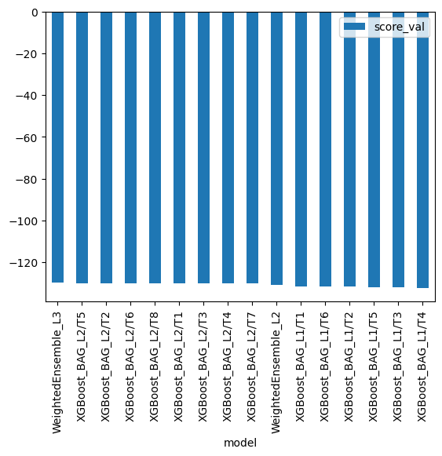

```python
predictor_new_hpo.leaderboard(silent=True).plot(kind="bar", x="model", y="score_val")
```

```python
predictions_new_hpo = predictor_new_hpo.predict(test)
predictions_new_hpo.head()
```

```
0    78.385506
1    56.533630
2    56.533630
3    79.270523
4    79.270523
Name: count, dtype: float32
```

```python
predictions_new_hpo.describe()
```

```
count    6493.000000
mean      202.428986
std       127.918449
min        29.792322
25%        99.935661
50%       166.397888
75%       275.715088
max       606.289551
Name: count, dtype: float64
```

```python
# Remember to set all negative values to zero
#for index, value in predictions_new_hpo.items():
#    if value <= 0:
#        predictions_new_hpo[index] = 0
#
#predictions_new_hpo.describe()

# Not necessary since minimum is 29.792322.
```

```python
# Same submitting predictions
submission_new_hpo = pd.read_csv('sampleSubmission.csv')
submission_new_hpo['datetime'] = pd.to_datetime(submission_new_hpo["datetime"])
submission_new_hpo.info()
```

```
<class 'pandas.core.frame.DataFrame'>
RangeIndex: 6493 entries, 0 to 6492
Data columns (total 2 columns):
 #   Column    Non-Null Count  Dtype
---  ------    --------------  -----
 0   datetime  6493 non-null   datetime64[ns]
 1   count     6493 non-null   int64
dtypes: datetime64[ns](1), int64(1)
memory usage: 101.6 KB
```

```python
submission_new_hpo["count"] = predictions_new_hpo
submission_new_hpo.to_csv("submission_new_hpo.csv", index=False)
```

```python
!kaggle competitions submit -c bike-sharing-demand -f submission_new_hpo.csv -m "new features with hyperparameters - 2nd try"
```

```
Successfully submitted to Bike Sharing Demand
```

```python
!kaggle competitions submissions -c bike-sharing-demand | tail -n +1 | head -n 6
```

```
fileName                     date                 description                                  status    publicScore  privateScore
---------------------------  -------------------  -------------------------------------------  --------  -----------  ------------
submission_new_hpo.csv       2024-04-17 12:51:53  new features with hyperparameters - 2nd try  complete  1.34311      1.34311
submission_new_hpo.csv       2024-04-16 16:15:38  new features with hyperparameters            complete  0.6241       0.6241
submission_new_features.csv  2024-04-16 15:20:20  new features                                 complete  0.74796      0.74796
submission.csv               2024-04-15 22:33:08  first raw submission                         complete  1.79568      1.79568
```